# SuperMap tutorial

In this tutorial, we demonstrate the usage of SuperMap in integrative analyses of unpaired single-cell multimodal data. Here, we showcase an example of integrating RNA and ATAC modality. We use a 10X Multimodal PBMC data download from [10X Genomics website](https://www.10xgenomics.com/datasets), which contains scRNA-seq and scATAC-seq profiles.

## Necessary packages

In order to run this vignette, make sure the following packages are installed:

```r
library(SuperMap)
library(dplyr)
library(ggplot2)
library(Seurat)
library(Signac)
library(GenomicRanges)
library(GenomeInfoDb)
library(EnsDb.Hsapiens.v86)
library(Matrix)
library(stringr)
library(tidyr)
library(RColorBrewer)
library(BiocParallel)
```

## Stage 1: Data processing

We begin by loading the downloaded dataset, which includes both scRNA-seq and scATAC-seq measurements.

```r
inputdata.10x <- Read10X_h5("pbmc_granulocyte_sorted_10k_filtered_feature_bc_matrix.h5") ## Read data from the file
```

```
## Genome matrix has multiple modalities, returning a list of matrices for this genome
```

```r
rna_counts <- inputdata.10x$`Gene Expression`
atac_counts <- inputdata.10x$Peaks
cell_type = readRDS('cell_type.RDS')
```

We create SeuratObject for the RNA and ATAC data, then perform preprocessing for each modality.

```r
pbmc_rna <- CreateSeuratObject(counts = rna_counts[,rownames(cell_type)],assay = 'RNA')    ## Creat SeuratObject

annotations <- GetGRangesFromEnsDb(ensdb = EnsDb.Hsapiens.v86)
seqlevels(annotations) <- paste0('chr', seqlevels(annotations))
genome(annotations) <- "hg38"
pbmc_atac = CreateChromatinAssay(counts = atac_counts[,rownames(cell_type)],sep = c(":", "-"),annotation = annotations, fragments = 'pbmc_granulocyte_sorted_10k_atac_fragments.tsv.gz')
```

```
## Computing hash
```

```r
pbmc_atac <- CreateSeuratObject(counts = pbmc_atac,assay = "ATAC")
```

Next, for RNA modality, we perform data normalization and dimensional reduction for visualization, following the Seurat pipeline. If you are unfamiliar with this workflow, please refer to their tutorial.

```r
pbmc_rna = NormalizeData(object = pbmc_rna)
```

```
## Normalizing layer: counts
```

```r
pbmc_rna = FindVariableFeatures(pbmc_rna,nfeatures = 2000)
```

```
## Finding variable features for layer counts
```

```r
pbmc_rna = ScaleData(pbmc_rna)
pbmc_rna = RunPCA(pbmc_rna,features = VariableFeatures(object = pbmc_rna),verbose = FALSE)
pbmc_rna = FindNeighbors(object = pbmc_rna, reduction = 'pca', dims = 1:50)
pbmc_rna = RunUMAP(pbmc_rna,dims = 1:50)
```

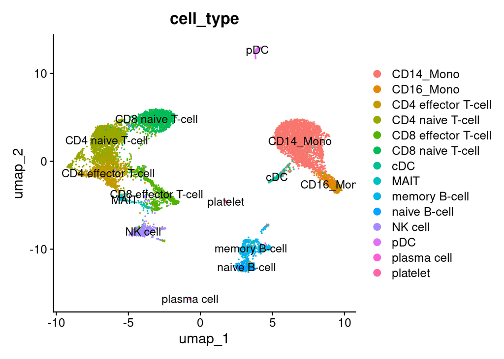

```r
pbmc_rna$cell_type = cell_type[colnames(pbmc_rna),'name']
DimPlot(pbmc_rna,reduction = 'umap',label = TRUE,group.by = 'cell_type')
```

We further perform preprocessing and visualization for ATAC data.

```r
pbmc_atac = RunTFIDF(pbmc_atac)
```

```
## Performing TF-IDF normalization
```

```r
pbmc_atac = FindTopFeatures(pbmc_atac, min.cutoff = 'q0')
pbmc_atac = RunSVD(pbmc_atac)
```

```
## Running SVD
```

```
## Scaling cell embeddings
```

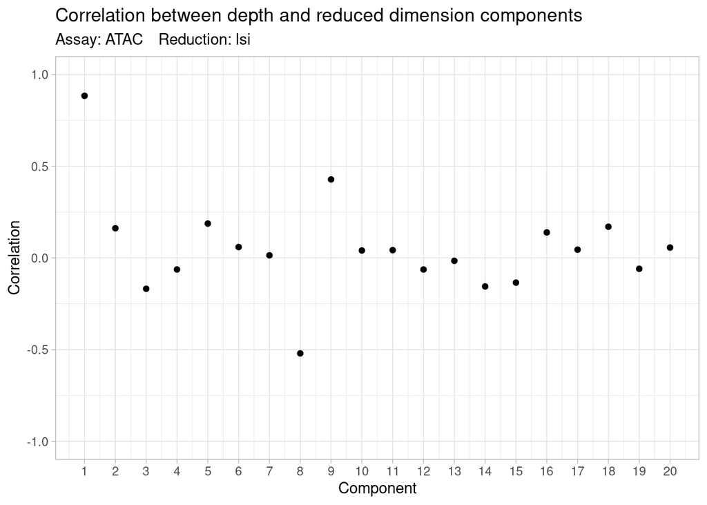

```r
DepthCor(pbmc_atac,n = 20)
```

```r
pbmc_atac = FindNeighbors(object = pbmc_atac, reduction = 'lsi', dims = 2:50)
pbmc_atac = RunUMAP(pbmc_atac, reduction = 'lsi', dims = 2:50)
```

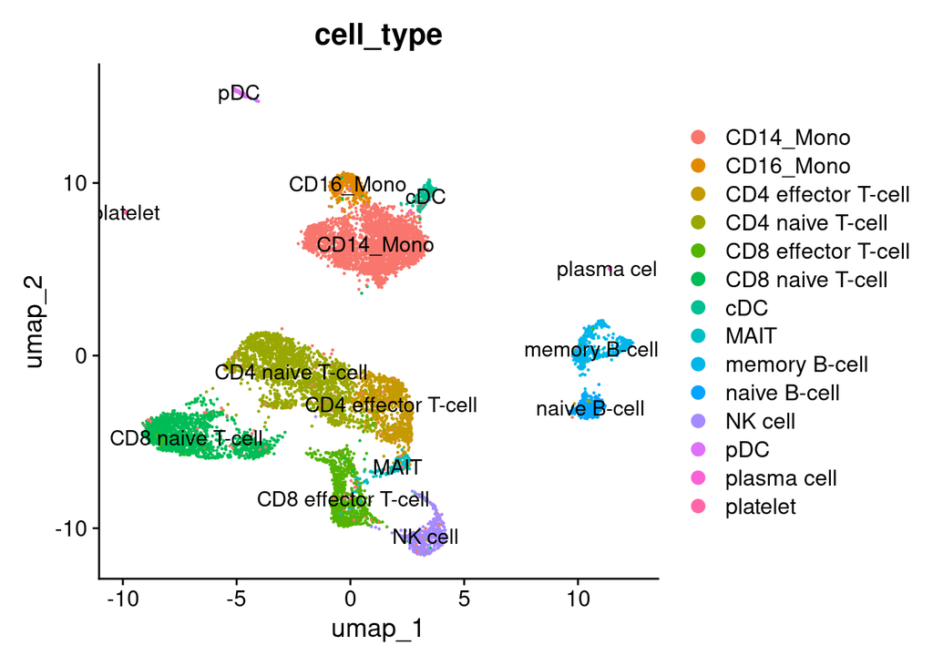

```r
pbmc_atac$cell_type = cell_type[colnames(pbmc_atac),'name']
DimPlot(pbmc_atac,reduction = 'umap',label = TRUE,group.by = 'cell_type')
```

## Stage 2: Metacell construction

In practice, due to the high sparsity and noise inherent in single-cell data, directly learning cross-modal mappings from the single-cell level data is challenging. To address this, SuperMap follows the approach established in previous studies by aggregating closely similar cells into ‘’meta-cell’’ to enhance the signal-to-noise ratio. Next, we demonstrate how to construct the meta-cell data.

```r
## The clustering resolution can be flexibly adjusted
pbmc_rna = metacell_construct(object = pbmc_rna, resolution = 25, graph.name = 'RNA_snn')
```

```
## Modularity Optimizer version 1.3.0 by Ludo Waltman and Nees Jan van Eck
##
## Number of nodes: 10531
## Number of edges: 488046
##
## Running Louvain algorithm...
## Maximum modularity in 10 random starts: 0.3466
## Number of communities: 159
## Elapsed time: 1 seconds
```

```
## 5 singletons identified. 154 final clusters.
```

```r
pbmc_atac = metacell_construct(object = pbmc_atac, resolution = 25, graph.name = 'ATAC_snn')
```

```
## Modularity Optimizer version 1.3.0 by Ludo Waltman and Nees Jan van Eck
##
## Number of nodes: 10531
## Number of edges: 422981
##
## Running Louvain algorithm...
## Maximum modularity in 10 random starts: 0.4098
## Number of communities: 170
## Elapsed time: 1 seconds
```

```
## 2 singletons identified. 168 final clusters.
```

```r
## The clustering resolution can be flexibly adjusted

metacell_rna <- metacell_matrix_RNA(object = pbmc_rna,cluster.name = "seurat_clusters")
metacell_atac <- metacell_matrix_ATAC(object = pbmc_atac,cluster.name = "seurat_clusters")
```

At this point, we obtained metacell-level data for model fitting.

## Stage 3: Computing peak-gene distance

When integrating scRNA-seq and scATAC-seq data, SuperMap incorporates genomic proximity as prior knowledge to regularize the model. Therefore, we need to compute the genomic distances between genes in the RNA modality and peaks in the ATAC modality. The highly variable genes are extracted for subsequent analysis. If you have other genes of interest, you can also include them.

```r
gene_annotation = read.table('~/pbmc_pair_cpm/GRCh38_cellranger2020.gene_location.txt',sep = ' ',header = TRUE)   ## Read the genomic coordinates of all genes.

variable_gene = VariableFeatures(pbmc_rna,assay = 'RNA')
metacell_rna = metacell_rna[,variable_gene]

supermap_data = gene_peak_distance(rna = metacell_rna, atac = metacell_atac,gene_annotation = gene_annotation)
```

## Stage 4: Run SuerpMap

At this stage, we run SuperMap on the preprocessed data to fit the model and learn the cross-modal mappings.

```r
learned_mappings = supermap(input_data = supermap_data)
```

The returned results include the convergence information of the model and the estimated parameters. We first plot the convergence curve for this run to check the iteration process.

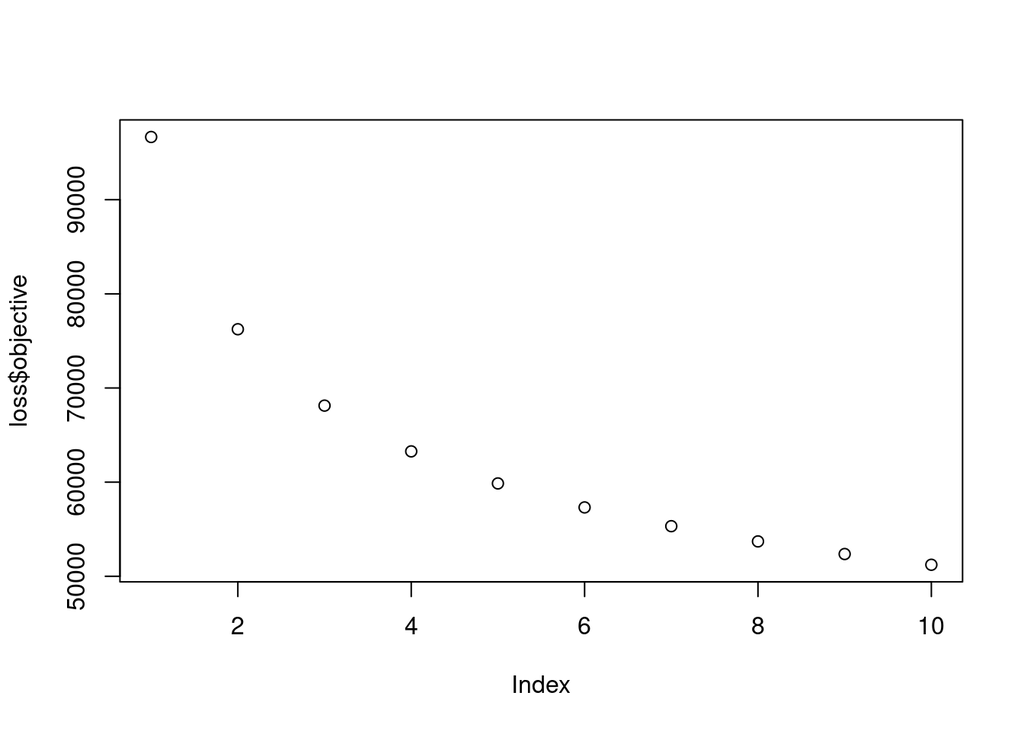

```r
loss = learned_mappings$convergence
loss = as.data.frame(loss)

colnames(loss) = c('residual','objective')
loss$iter = c(1:nrow(loss))

plot(loss$objective)
```

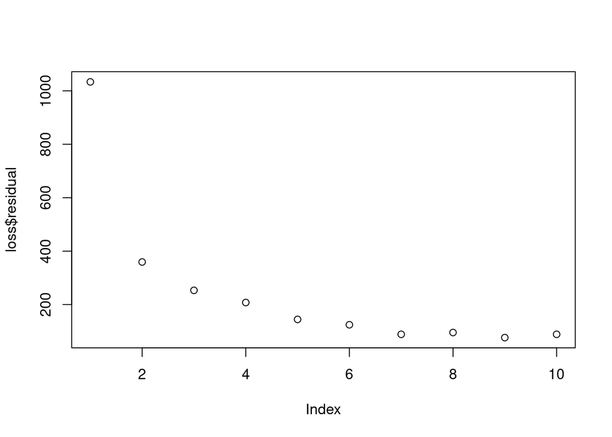

```r
plot(loss$residual)
```

We observed that the objective function steadily converged over iterations.

## Stage 4: Imputating missing modality

The learned mappings can be used for extensive downstream integrative analyses of unpaired multimodal data, including imputing missing modalities to enhance cell type identification. Below, we demonstrate how to predict RNA expression from chromatin accessibility.

```r
imputation_data = imputation(supermap_data = supermap_data,learned_mappings = learned_mappings,atac=pbmc_atac)
```

After obtaining the imputed RNA expression profiles, we can use marker gene signals to interpret the cell clusters. We visualized the expression patterns of several representative marker genes to facilitate biological interpretation.

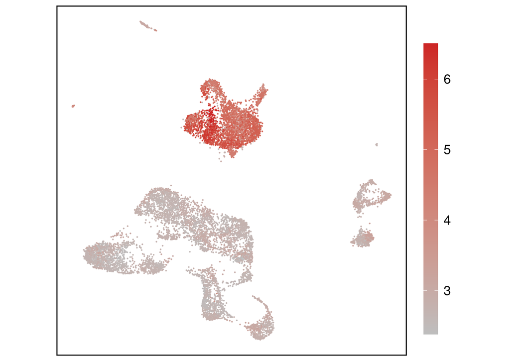

```r
cell_umap = pbmc_atac@reductions$umap@cell.embeddings
cell_umap = as.data.frame(cell_umap)
cell_umap$imputed_value = imputation_data[rownames(cell_umap),'CD14']
marker_plot(cell_umap = cell_umap)
```

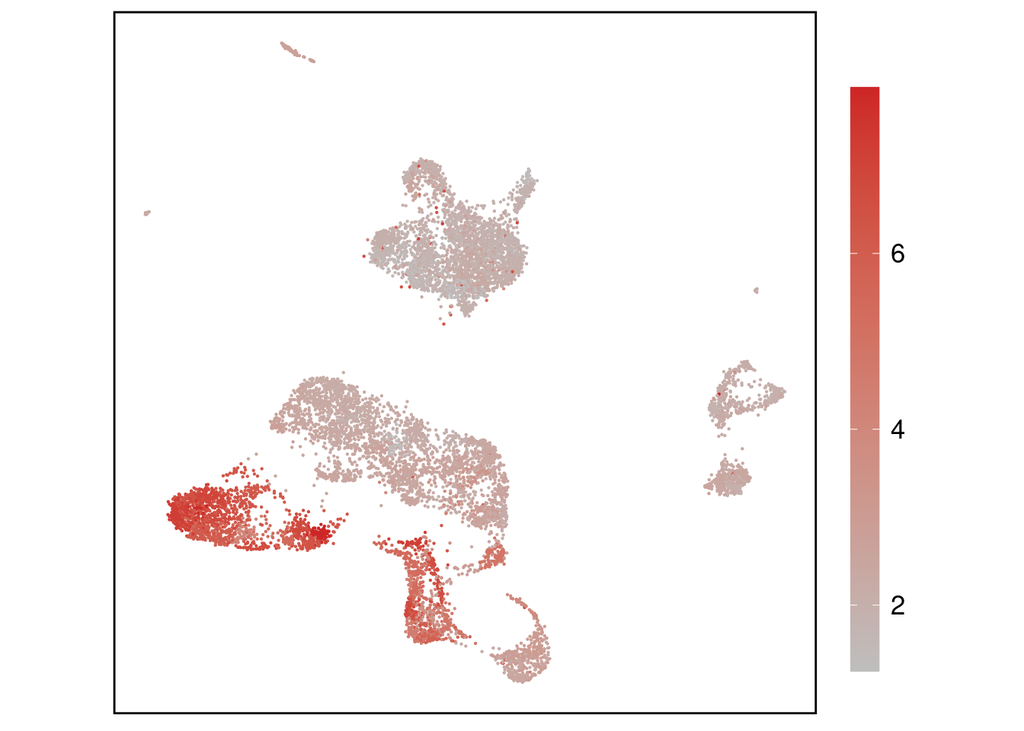

```r
cell_umap = pbmc_atac@reductions$umap@cell.embeddings
cell_umap = as.data.frame(cell_umap)
cell_umap$imputed_value = imputation_data[rownames(cell_umap),'CD8B']
marker_plot(cell_umap = cell_umap)
```

## Stage 5: Performing diagonal integration

SuperMap can facilitate diagonal integration by leveraging its learned mappings as effective alignment anchors. To operationalize this idea, we propose an integration procedure that harnesses the complementary strengths of both SuperMap and Seurat. In this procedure, the ‘’gene activity score’’ utilized by Seurat is replaced with the imputed RNA profiles generated by SuperMap. The procedure for performing diagonal integration using Seurat can be found in their vignette (https://satijalab.org/seurat/articles/seurat5_atacseq_integration_vignette). In the following, we demonstrate how to perform diagonal integration using SuperMap.

```r
integration_result = diagonal_integration(supermap_data = supermap_data,learned_mappings = learned_mappings, rna = pbmc_rna,atac = pbmc_atac,rna_label = cell_type)
```

```
## Normalizing layer: counts
```

```
## Running CCA
```

```
## Merging objects
```

```
## Finding neighborhoods
```

```
## Finding anchors
```

```
##  Found 838 anchors
```

```
## Running PCA on query dataset
```

```
## Finding integration vectors
```

```
## Finding integration vector weights
```

```
## Transfering 1955 features onto reference data
```

```
## Running PCA on query dataset
```

```
## Finding integration vectors
```

```
## Finding integration vector weights
```

```
## Predicting cell labels
```

```
## Normalizing layer: counts
```

```
## Centering data matrix
```

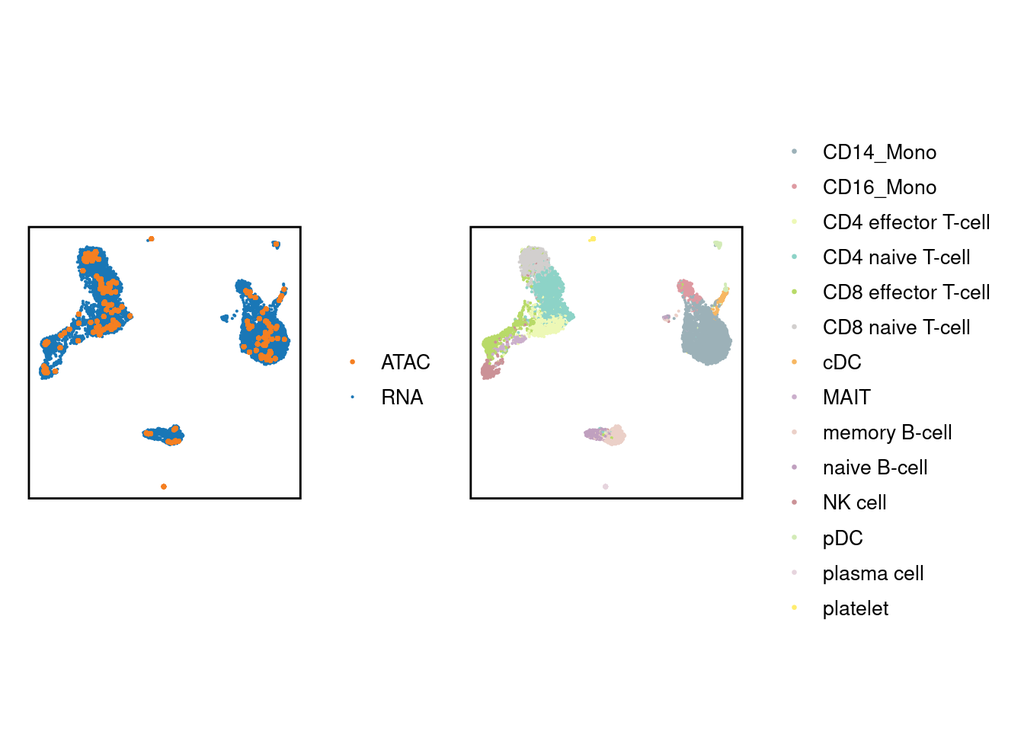

```r
integrated_embedding = integration_result$pca
integrated_umap = integration_result$umap
batch_plot(umap = integrated_umap,rna_cell_size = ncol(pbmc_rna))+
  cell_type_plot(umap = integrated_umap, rna_cell_size = ncol(pbmc_rna),rna_label = cell_type, atac_label = integration_result$predicted_label)
```

During the imputation, the deconvolution step results in multiple ATAC cells within the same meta-cell sharing identical imputed profiles, which in turn leads to overlapping embedding coordinates in the joint latent space. This gives the visual illusion that there are fewer ATAC cells, even though the actual number of ATAC cells equals that of RNA cells in this gold-standard dataset. For a detailed description of the method, please refer to our paper.